# The Data Incubator Fellowship Program

Chart 1

Andrej Arpáš

4/24/2020

# 1 Justification a.k.a. *The Huddled Masses* 2.0: Give Me Your Poor No More?

With the recent [decision](https://www.whitehouse.gov/briefings-statements/president-donald-j-trump-honoring-commitment-protect-american-workers-temporarily-pausing-immigration/) to temporarily suspend new immigrant visas, immigration is again on a lot of people’s minds. While nonimmigrant visas, including work authorizations like the much sought-after H-1B type visas, pertain to another visa category, the clampdown - however provisional - on immigrant visas, together with the entire COVID-19 situation, has made the already uneasy hiring process more uncertain and tumultuous for everybody involved, from employers to H-1B seekers. Luckily, uncertainty is statisticians’ daily bread. Questions to do with stochasticity, optimization, and Bayesian statistics come to the fore. Under these strenuous circumstances, how might we best plug foreigners in the U.S. job market, such that parameters like the approval rate on the one hand, or wage-yields of fresh graduates on the other, are optimized? Here at Columbia, we have long been in the vanguard of developing solutions to deal with these kinds of pressing industry questions with the help of Stan. Using Stan, this project aims at getting to the bottom of these and other questions, with the help of posterior distributions, while taking into account the latest data in the field.

## 1.1 Data

The U.S. Labor Department’s Office of Foreign Labor Certification (OFLC) uses a designated [website](https://www.foreignlaborcert.doleta.gov/performancedata.cfm) that serves as the repository of the latest labor statistics pertaining to immigration/work visas and the like, with datasets parsed by Fiscal Year (e.g. the Federal government’s FY 2019 went from October 1, 2018, through September 30, 2019), and including roughly 34 variables such as, *inter alia*, Foreign Workers’ Country of Origin, Country of Birth, Wage, Class of Admission, their university Major, the name of the University itself, Size of the Employer, NAICS code of the job, and many, many others. Honing in on one kind of visa in particular, the coveted H-1Bs, let’s look into the latest complete dataset, which is FY 2019.

Load the data…

Some cleaning and subset…

```r
d.sub <- subset(d, select = c("emp_name", "emp_city", "emp_size", "wage", "job_city", # Subsetting for H-1Bs and leaving behind what's extraneous.
                              "job_state", "job_edu", "job_major", "fw_coc", "fw_cob", # fw_coc Foreign Worker - Country of Citizenship, fw_cob Foreign Worker - Country of Birth
                              "fw_class_of_admission", "fw_edu", "fw_major", "fw_edu_yrs", "fw_edu_name",
                              "naics_code", "naics_title"),
                fw_class_of_admission == "H-1B")
```

Let’s look at the top ten…

```r
# library(tidyverse)
d.sub %>% na.omit() %>% group_by(fw_cob) %>% summarize(n = n()) %>% top_n(n = 10) %>% arrange(desc(n))
```

```
## # A tibble: 10 x 2
##    fw_cob              n
##    <fct>           <int>
##  1 INDIA          158037
##  2 CHINA           24609
##  3 SOUTH KOREA      4242
##  4 PHILIPPINES      2743
##  5 CANADA           2551
##  6 MEXICO           2284
##  7 TAIWAN           2208
##  8 PAKISTAN         1602
##  9 NEPAL            1577
## 10 UNITED KINGDOM   1490
```

Now, we might want to see the kinds of schools that, say, pertain to the top five H-1B visa holders’ category as parsed by the Country of Birth…

```r
d.sub %>% na.omit() %>% filter(fw_cob == "INDIA") %>% group_by(fw_edu_name) %>% summarize(n = n()) %>% top_n(n = 10) %>% arrange(desc(n))
```

```
## # A tibble: 10 x 2
##    fw_edu_name                                         n
##    <fct>                                           <int>
##  1 JAWAHARLAL NEHRU TECHNOLOGICAL UNIVERSITY        7521
##  2 ANNA UNIVERSITY                                  6391
##  3 UNIVERSITY OF MADRAS                             3773
##  4 OSMANIA UNIVERSITY                               3723
##  5 UNIVERSITY OF MUMBAI                             2603
##  6 UNIVERSITY OF PUNE                               2477
##  7 VISVESWARAIAH TECHNOLOGICAL UNIVERSITY, BELGAUM  2050
##  8 ANDHRA UNIVERSITY                                2049
##  9 UNIVERSITY OF SOUTHERN CALIFORNIA                1997
## 10 VISVESWARAIAH TECHNOLOGICAL UNIVERSITY           1643
```

```r
d.sub %>% na.omit() %>% filter(fw_cob == "CHINA") %>% group_by(fw_edu_name) %>% summarize(n = n()) %>% top_n(n = 10) %>% arrange(desc(n))
```

```
## # A tibble: 10 x 2
##    fw_edu_name                               n
##    <fct>                                 <int>
##  1 CARNEGIE MELLON UNIVERSITY             1099
##  2 UNIVERSITY OF SOUTHERN CALIFORNIA      1002
##  3 COLUMBIA UNIVERSITY                     782
##  4 CORNELL UNIVERSITY                      387
##  5 NEW YORK UNIVERSITY                     386
##  6 UNIVERSITY OF PENNSYLVANIA              353
##  7 UNIVERSITY OF CALIFORNIA, LOS ANGELES   300
##  8 UNIVERSITY OF MICHIGAN                  281
##  9 ILLINOIS INSTITUTE OF TECHNOLOGY        276
## 10 NORTHEASTERN UNIVERSITY                 265
```

```r
d.sub %>% na.omit() %>% filter(fw_cob == "SOUTH KOREA") %>% group_by(fw_edu_name) %>% summarize(n = n()) %>% top_n(n = 10) %>% arrange(desc(n))
```

```
## # A tibble: 11 x 2
##    fw_edu_name                            n
##    <fct>                              <int>
##  1 COLUMBIA UNIVERSITY                   69
##  2 CARNEGIE MELLON UNIVERSITY            67
##  3 UNIVERSITY OF PENNSYLVANIA            54
##  4 HANYANG UNIVERSITY                    51
##  5 ACADEMY OF ART UNIVERSITY             50
##  6 PURDUE UNIVERSITY                     49
##  7 UNIVERSITY OF SOUTHERN CALIFORNIA     48
##  8 UNIVERSITY OF MICHIGAN                47
##  9 UNIVERSITY OF CALIFORNIA, BERKELEY    45
## 10 GEORGIA INSTITUTE OF TECHNOLOGY       44
## 11 THE OHIO STATE UNIVERSITY             44
```

```r
d.sub %>% na.omit() %>% filter(fw_cob == "PHILIPPINES") %>% group_by(fw_edu_name) %>% summarize(n = n()) %>% top_n(n = 10) %>% arrange(desc(n))
```

```
## # A tibble: 10 x 2
##    fw_edu_name                       n
##    <fct>                         <int>
##  1 UNIVERSITY OF SANTO TOMAS       203
##  2 UNIVERSITY OF THE PHILIPPINES    89
##  3 DE LA SALLE UNIVERSITY           84
##  4 VELEZ COLLEGE                    79
##  5 MAPUA INSTITUTE OF TECHNOLOGY    64
##  6 PHILIPPINE NORMAL UNIVERSITY     56
##  7 UNIVERSITY OF SAN CARLOS         56
##  8 SAINT LOUIS UNIVERSITY           52
##  9 SOUTHWESTERN UNIVERSITY          50
## 10 FAR EASTERN UNIVERSITY           49
```

```r
d.sub %>% na.omit() %>% filter(fw_cob == "CANADA") %>% group_by(fw_edu_name) %>% summarize(n = n()) %>% top_n(n = 10) %>% arrange(desc(n))
```

```
## # A tibble: 11 x 2
##    fw_edu_name                        n
##    <fct>                          <int>
##  1 UNIVERSITY OF WATERLOO           198
##  2 UNIVERSITY OF TORONTO            145
##  3 MCGILL UNIVERSITY                102
##  4 UNIVERSITY OF BRITISH COLUMBIA    69
##  5 UNIVERSITY OF ALBERTA             53
##  6 QUEEN'S UNIVERSITY                51
##  7 CONCORDIA UNIVERSITY              48
##  8 THE UNIVERSITY OF WATERLOO        48
##  9 CARLETON UNIVERSITY               42
## 10 MCMASTER UNIVERSITY               38
## 11 UNIVERSITY OF WESTERN ONTARIO     38
```

Alright, off to those charts then, let’s see what we can see off-the-bat…

First plot…

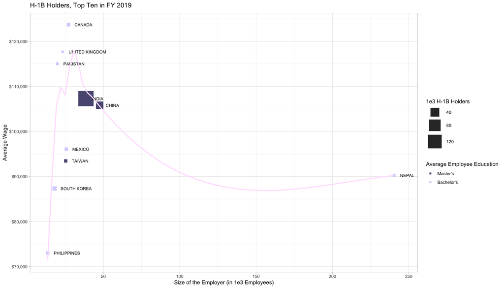